# Capstone Project: Create a Customer Segmentation Report for Arvato Financial Services

#### 3.3.2 Select features with Random Forest classifier

```python
# fit random forest to select features
feature_selector = ExtraTreesClassifier(n_estimators=250, max_depth=1, random_state=10)
feature_selector.fit(pre_pipe.fit_transform(X_train), y_train)
```

```
ExtraTreesClassifier(bootstrap=False, class_weight=None, criterion='gini',
                     max_depth=1, max_features='auto', max_leaf_nodes=None,
                     min_impurity_decrease=0.0, min_impurity_split=None,
                     min_samples_leaf=1, min_samples_split=2,
                     min_weight_fraction_leaf=0.0, n_estimators=250,
                     n_jobs=None, oob_score=False, random_state=10, verbose=0,
                     warm_start=False)
```

```python
# get and print most-relevant features
importances = feature_selector.feature_importances_
indices = np.argsort(importances)[::-1]

last_index = np.sum(importances >= 0.0)

# print the feature ranking
print("Feature ranking:")

for f in range(last_index):
    print('{:d}. {} ({:.4f})'.format(f+1, mailout_data_cleaned.columns[indices[f]], importances[indices[f]]))
```

```
Feature ranking:
1. D19_KONSUMTYP_9.0 (0.0600)
2. RT_SCHNAEPPCHEN (0.0560)
3. D19_KONSUMTYP_3.0 (0.0480)
4. D19_SOZIALES (0.0400)
5. D19_BANKEN_DIREKT (0.0400)
6. LP_LEBENSPHASE_GROB_2.0 (0.0360)
7. LP_LEBENSPHASE_GROB_3.0 (0.0320)
8. KBA13_KW_30 (0.0320)
9. LP_LEBENSPHASE_GROB_4.0 (0.0280)
10. OST_WEST_KZ (0.0280)
11. D19_KONSUMTYP_4.0 (0.0240)
12. ANZ_TITEL (0.0240)
13. D19_KONSUMTYP_6.0 (0.0240)
14. ANZ_KINDER (0.0240)
15. KBA13_FIAT (0.0200)
16. KBA13_KMH_140_210 (0.0200)
17. RT_KEIN_ANREIZ (0.0200)
18. CJT_KATALOGNUTZER (0.0200)
19. FAMILY_WEALTH (0.0200)
20. FINANZ_SPARER (0.0200)
21. STRUKTURTYP (0.0160)
22. KOMBIALTER (0.0160)
23. KBA13_SEG_SPORTWAGEN (0.0160)
24. KBA05_CCM4 (0.0160)
25. KBA13_CCM_3000 (0.0160)
26. GFK_URLAUBERTYP_7.0 (0.0120)
27. KBA05_DIESEL (0.0120)
28. KBA13_KW_121 (0.0120)
29. KBA13_CCM_2501 (0.0120)
30. D19_BANKEN_LOKAL (0.0120)
31. KBA13_SEG_WOHNMOBILE (0.0120)
32. KBA05_KW2 (0.0120)
33. CJT_GESAMTTYP_4.0 (0.0080)
34. CJT_GESAMTTYP_1.0 (0.0080)
35. YOUTH_DECADE (0.0080)
36. D19_TIERARTIKEL (0.0080)
37. KBA05_ANTG3 (0.0080)
38. SEMIO_PFLICHT (0.0080)
39. KBA05_MOD1 (0.0080)
```

[output cut: 264 more lines]

```
304. KBA13_SEG_KOMPAKTKLASSE (0.0000)
305. KBA13_SEG_KLEINST (0.0000)
306. KBA13_SEG_GROSSRAUMVANS (0.0000)
307. KBA13_SEG_GELAENDEWAGEN (0.0000)
308. KBA13_RENAULT (0.0000)
309. KBA13_PEUGEOT (0.0000)
310. KBA13_OPEL (0.0000)
311. KBA13_NISSAN (0.0000)
312. KBA13_MOTOR (0.0000)
313. KBA13_MAZDA (0.0000)
314. KBA13_KW_90 (0.0000)
315. KBA13_KW_80 (0.0000)
316. KBA13_KW_70 (0.0000)
317. KBA13_KW_61_120 (0.0000)
318. ANZ_HAUSHALTE_AKTIV (0.0000)
```

**Observations:**

- the highest feature importance is 0.06; for most features the relevance is 0
- choose features with 0.01 and 0.005

```python
# select features with importance higher 0.01
last_index = np.sum(importances >= 0.01)

# print the feature ranking
print("Feature ranking:")

for f in range(last_index):
    print('{:d}. {} ({:.4f})'.format(f+1, mailout_data_cleaned.columns[indices[f]], importances[indices[f]]))
```

```
Feature ranking:
1. D19_KONSUMTYP_9.0 (0.0600)
2. RT_SCHNAEPPCHEN (0.0560)
3. D19_KONSUMTYP_3.0 (0.0480)
4. D19_SOZIALES (0.0400)
5. D19_BANKEN_DIREKT (0.0400)
6. LP_LEBENSPHASE_GROB_2.0 (0.0360)
7. LP_LEBENSPHASE_GROB_3.0 (0.0320)
8. KBA13_KW_30 (0.0320)
9. LP_LEBENSPHASE_GROB_4.0 (0.0280)
10. OST_WEST_KZ (0.0280)
11. D19_KONSUMTYP_4.0 (0.0240)
12. ANZ_TITEL (0.0240)
13. D19_KONSUMTYP_6.0 (0.0240)
14. ANZ_KINDER (0.0240)
15. KBA13_FIAT (0.0200)
16. KBA13_KMH_140_210 (0.0200)
17. RT_KEIN_ANREIZ (0.0200)
18. CJT_KATALOGNUTZER (0.0200)
19. FAMILY_WEALTH (0.0200)
20. FINANZ_SPARER (0.0200)
21. STRUKTURTYP (0.0160)
22. KOMBIALTER (0.0160)
23. KBA13_SEG_SPORTWAGEN (0.0160)
24. KBA05_CCM4 (0.0160)
25. KBA13_CCM_3000 (0.0160)
26. GFK_URLAUBERTYP_7.0 (0.0120)
27. KBA05_DIESEL (0.0120)
28. KBA13_KW_121 (0.0120)
29. KBA13_CCM_2501 (0.0120)
30. D19_BANKEN_LOKAL (0.0120)
31. KBA13_SEG_WOHNMOBILE (0.0120)
32. KBA05_KW2 (0.0120)
```

```python
# select most relevant features
X_train_reduced = X_train[:, indices[0:last_index]]
```

```
[learning_curve] Training set sizes: [ 2380  7142 11904 17856 23808]
```

```
[Parallel(n_jobs=-1)]: Using backend LokyBackend with 4 concurrent workers.
```

```
GradientBoost: ROC-AUC score = 0.8002 (0.0295)
```

```
[Parallel(n_jobs=-1)]: Done  25 out of  25 | elapsed:   45.0s finished
```

```
(0.8001777125883965, 0.02949852278466918)
```

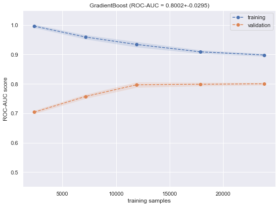

```python
# create classifier pipeline
clf_pipe = Pipeline(steps=[('prepare', pre_pipe), ('clf_GradientBoost', GradientBoostingClassifier())])

# assess performance of GradientBoost classifier on reduced feature set
screen_classifier(clf_pipe, cv, X_train_reduced, y_train, train_sizes, clf_name='GradientBoost')
```

```python
# select features with importance higher 0.005
last_index = np.sum(importances >= 0.005)

# print the feature ranking
print("Feature ranking:")

for f in range(last_index):
    print('{:d}. {} ({:.4f})'.format(f+1, mailout_data_cleaned.columns[indices[f]], importances[indices[f]]))
```

```
Feature ranking:
1. D19_KONSUMTYP_9.0 (0.0600)
2. RT_SCHNAEPPCHEN (0.0560)
3. D19_KONSUMTYP_3.0 (0.0480)
4. D19_SOZIALES (0.0400)
5. D19_BANKEN_DIREKT (0.0400)
6. LP_LEBENSPHASE_GROB_2.0 (0.0360)
7. LP_LEBENSPHASE_GROB_3.0 (0.0320)
8. KBA13_KW_30 (0.0320)
9. LP_LEBENSPHASE_GROB_4.0 (0.0280)
10. OST_WEST_KZ (0.0280)
11. D19_KONSUMTYP_4.0 (0.0240)
12. ANZ_TITEL (0.0240)
13. D19_KONSUMTYP_6.0 (0.0240)
14. ANZ_KINDER (0.0240)
15. KBA13_FIAT (0.0200)
16. KBA13_KMH_140_210 (0.0200)
17. RT_KEIN_ANREIZ (0.0200)
18. CJT_KATALOGNUTZER (0.0200)
19. FAMILY_WEALTH (0.0200)
20. FINANZ_SPARER (0.0200)
21. STRUKTURTYP (0.0160)
22. KOMBIALTER (0.0160)
23. KBA13_SEG_SPORTWAGEN (0.0160)
24. KBA05_CCM4 (0.0160)
25. KBA13_CCM_3000 (0.0160)
26. GFK_URLAUBERTYP_7.0 (0.0120)
27. KBA05_DIESEL (0.0120)
28. KBA13_KW_121 (0.0120)
29. KBA13_CCM_2501 (0.0120)
30. D19_BANKEN_LOKAL (0.0120)
31. KBA13_SEG_WOHNMOBILE (0.0120)
32. KBA05_KW2 (0.0120)
33. CJT_GESAMTTYP_4.0 (0.0080)
34. CJT_GESAMTTYP_1.0 (0.0080)
35. YOUTH_DECADE (0.0080)
36. D19_TIERARTIKEL (0.0080)
37. KBA05_ANTG3 (0.0080)
38. SEMIO_PFLICHT (0.0080)
39. KBA05_MOD1 (0.0080)
40. FINANZ_VORSORGER (0.0080)
41. W_KEIT_KIND_HH (0.0080)
42. HH_EINKOMMEN_SCORE (0.0080)
43. KBA05_KRSKLEIN (0.0080)
44. KBA13_SITZE_4 (0.0080)
45. KBA05_ALTER3 (0.0080)
46. KBA13_SEG_KLEINWAGEN (0.0080)
47. D19_KINDERARTIKEL (0.0080)
```

```python
# select most relevant features
X_train_reduced = X_train[:, indices[0:last_index]]
```

```
[learning_curve] Training set sizes: [ 2380  7142 11904 17856 23808]
```

```
[Parallel(n_jobs=-1)]: Using backend LokyBackend with 4 concurrent workers.
```

```
GradientBoost: ROC-AUC score = 0.8017 (0.0327)
```

```
[Parallel(n_jobs=-1)]: Done  25 out of  25 | elapsed:  1.1min finished
```

```
(0.8016796483451809, 0.032730130983072224)
```

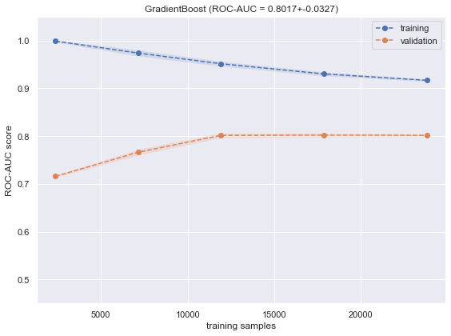

```python
# create classifier pipeline
clf_pipe = Pipeline(steps=[('prepare', pre_pipe), ('clf_GradientBoost', GradientBoostingClassifier())])

# assess performance of GradientBoost classifier on reduced feature set
screen_classifier(clf_pipe, cv, X_train_reduced, y_train, train_sizes, clf_name='GradientBoost')
```

**Observations**

- including features with a feature importance higher 0.005 yields promising results
  - the ROC-AUC score is 0.80
  - the validation score converges at 0.80 and the training score decreases slightly
    - more model complexity (variance) will be introduced by tuning of the hyper-parameters

### x.3 Tune hyper-parameters

```python
# create classifier pipeline
clf_pipe = Pipeline(steps=[('prepare', pre_pipe),
                           ('clf_GradientBoost', GradientBoostingClassifier(random_state=10))])
```

```python
# parameters
n_estimators = [50, 100, 200, 250]
learning_rate = [0.01, 0.05, 0.1, 0.2, 0.5, 1.0]
max_depth = [1, 2, 3, 4, 5]
subsample = [0.1, 0.2, 0.5, 0.8, 1.0]
max_features = [0.1, 0.2, 0.5, 0.8, 1.0]

parameters = {'clf_GradientBoost__n_estimators': n_estimators,
              'clf_GradientBoost__learning_rate': learning_rate,
              'clf_GradientBoost__max_depth': max_depth,
              'clf_GradientBoost__subsample': subsample,
              'clf_GradientBoost__max_features': max_features}
```

```python
# make sure the right reduced feature space is used
X_train_reduced.shape
```

```
(29760, 47)
```

```python
# optimize hyper-parameters using randomized search
opt = RandomizedSearchCV(clf_pipe, param_distributions=parameters, scoring='roc_auc', cv=cv,
                         n_iter=300, verbose=2, n_jobs=-1, random_state=10)

opt.fit(X_train_reduced, y_train);
```

```
Fitting 5 folds for each of 300 candidates, totalling 1500 fits
```

```
[Parallel(n_jobs=-1)]: Using backend LokyBackend with 4 concurrent workers.
[Parallel(n_jobs=-1)]: Done  33 tasks      | elapsed:  3.7min
[Parallel(n_jobs=-1)]: Done 154 tasks      | elapsed:  9.3min
[Parallel(n_jobs=-1)]: Done 357 tasks      | elapsed: 17.3min
[Parallel(n_jobs=-1)]: Done 640 tasks      | elapsed: 29.2min
[Parallel(n_jobs=-1)]: Done 1005 tasks      | elapsed: 356.8min
[Parallel(n_jobs=-1)]: Done 1450 tasks      | elapsed: 385.4min
[Parallel(n_jobs=-1)]: Done 1500 out of 1500 | elapsed: 388.5min finished
```

```python
# store best estimator
best_clf = opt.best_estimator_

# show configuration of best estimator
best_clf
```

```
Pipeline(memory=None,
         steps=[('prepare',
                 Pipeline(memory=None,
                          steps=[('impute',
                                  SimpleImputer(add_indicator=False, copy=True,
                                                fill_value=None,
                                                missing_values=nan,
                                                strategy='median', verbose=0)),
                                 ('scale',
                                  StandardScaler(copy=True, with_mean=True,
                                                 with_std=True))],
                          verbose=False)),
                ('clf_GradientBoost',
                 GradientBoostingClassifier(criterion='friedman_mse', init=None,
                                            learning_rate=0.05, loss='deviance',
                                            max_depth=3, max_features=0.2,
                                            max_leaf_nodes=None,
                                            min_impurity_decrease=0.0,
                                            min_impurity_split=None,
                                            min_samples_leaf=1,
                                            min_samples_split=2,
                                            min_weight_fraction_leaf=0.0,
                                            n_estimators=250,
                                            n_iter_no_change=None,
                                            presort='auto', random_state=10,
                                            subsample=0.5, tol=0.0001,
                                            validation_fraction=0.1, verbose=0,
                                            warm_start=False))],
         verbose=False)
```

```
[learning_curve] Training set sizes: [ 2380  7142 11904 17856 23808]
```

```
[Parallel(n_jobs=-1)]: Using backend LokyBackend with 4 concurrent workers.
```

```
optimized GradientBoost: ROC-AUC score = 0.8016 (0.0328)
```

```
[Parallel(n_jobs=-1)]: Done  25 out of  25 | elapsed:   53.5s finished
```

```
(0.8016244723798314, 0.03279030028439938)
```

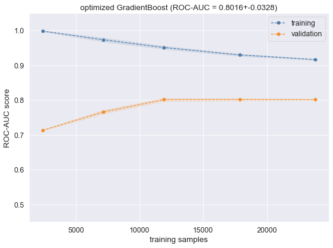

```python
# create learning curve for optimized classifier
screen_classifier(best_clf, cv, X_train_reduced, y_train, train_sizes, clf_name='optimized GradientBoost')
```

```python
# predict class probabilities using best set of hyper-parameters
y_prob = best_clf.predict_proba(X_test[:, indices[0:last_index]])[:,1]
```

```python
# calculate ROC-AUC score for test data
roc_auc_score(y_test, y_prob)
```

```
0.7678968828879961
```

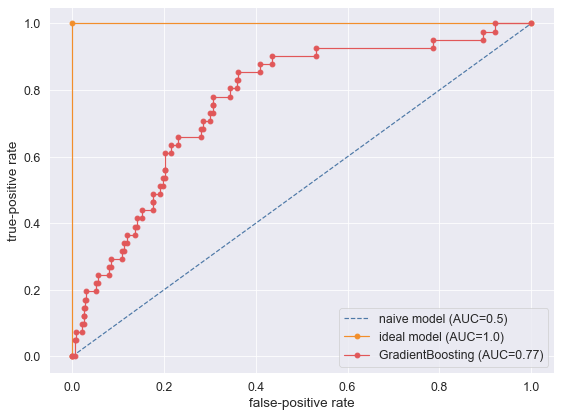

```python
# create ROC plot

# calculate false-positive rate and true-positive rate
fpr, tpr, tresh = roc_curve(y_test, y_prob)

# plot ROC curve
fig = plt.figure(figsize=(8,6))
plt.plot([0.0, 1.0], [0.0, 1.0], '--', label='naive model (AUC=0.5)')
plt.plot([0.0, 0.0, 1.0], [0.0, 1.0, 1.0], 'o-', label='ideal model (AUC=1.0)')
plt.plot(fpr, tpr, 'o-', label='GradientBoosting (AUC=0.77)')
plt.xlabel('false-positive rate')
plt.ylabel('true-positive rate')
plt.legend(loc=0)
fig.tight_layout()
fig.savefig('plots/ROC.png', dpi=300.0)
```

## Part 4: Kaggle Competition

Now that you've created a model to predict which individuals are most likely to respond to a mailout campaign, it's time to test that model in competition through Kaggle. If you click on the link [here](http://www.kaggle.com/t/21e6d45d4c574c7fa2d868f0e8c83140), you'll be taken to the competition page where, if you have a Kaggle account, you can enter. If you're one of the top performers, you may have the chance to be contacted by a hiring manager from Arvato or Bertelsmann for an interview!

Your entry to the competition should be a CSV file with two columns. The first column should be a copy of "LNR", which acts as an ID number for each individual in the "TEST" partition. The second column, "RESPONSE", should be some measure of how likely each individual became a customer – this might not be a straightforward probability. As you should have found in Part 2, there is a large output class imbalance, where most individuals did not respond to the mailout. Thus, predicting individual classes and using accuracy does not seem to be an appropriate performance evaluation method. Instead, the competition will be using AUC to evaluate performance. The exact values of the "RESPONSE" column do not matter as much: only that the higher values try to capture as many of the actual customers as possible, early in the ROC curve sweep.

```python
# read test data
mailout_test = pd.read_csv('./arvato_data/Udacity_MAILOUT_052018_TEST.csv', sep=';')
```

```python
# get LNR column for submission file
lnr = mailout_test['LNR']
```

```python
# clean test data without removing lines though as predictions for all entries are required
mailout_test_cleaned = clean_data(mailout_test, missing_list, remove_lines=False, impute=False)
```

```python
# assign features
X = mailout_test_cleaned.values

# select relevant features
X_test_final = X[:, indices[0:last_index]]
```

```python
# predict probabilities
y_prob_final = best_clf.predict_proba(X_test_final)[:, 1]
```

```python
# create dataframe from predictions
df_kaggle = pd.DataFrame(index=lnr, columns=['RESPONSE'], data=y_prob_final)
```

```python
# save predictions to csv for upload
df_kaggle.to_csv('kaggle_submission_v04.csv')
```